# HW2_sol

```python
import matplotlib.pyplot as plt
import numpy as np
```

### Example 1-1

基本np.array與matplotlib繪圖

```
[2 4 6 8]
[ 1  4  9 16]
```

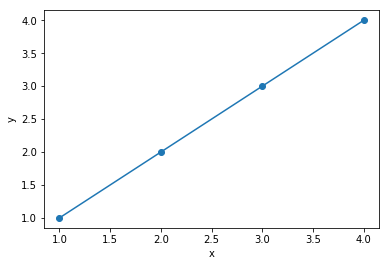

```python
A = np.array([1,2,3,4])
B = np.array([1,2,3,4])
print(A+B)
print(A*B)
plt.plot(A, B, '-o')
plt.xlabel('x')
plt.ylabel('y')
plt.show()
```

### Example 1-2

基本np.array與matplotlib繪圖

```
[0.         0.33069396 0.66138793 0.99208189 1.32277585 1.65346982
 1.98416378 2.31485774 2.64555171 2.97624567 3.30693964 3.6376336
 3.96832756 4.29902153 4.62971549 4.96040945 5.29110342 5.62179738
 5.95249134 6.28318531]
[ 0.00000000e+00  3.24699469e-01  6.14212713e-01  8.37166478e-01
  9.69400266e-01  9.96584493e-01  9.15773327e-01  7.35723911e-01
  4.75947393e-01  1.64594590e-01 -1.64594590e-01 -4.75947393e-01
 -7.35723911e-01 -9.15773327e-01 -9.96584493e-01 -9.69400266e-01
 -8.37166478e-01 -6.14212713e-01 -3.24699469e-01 -2.44929360e-16]
```

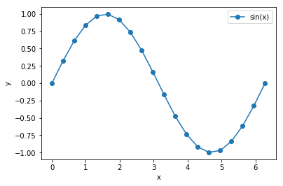

```python
xArr = np.linspace(0, 2*np.pi, 20)
yArr = np.sin(xArr)
print(xArr)
print(yArr)
plt.plot(xArr, yArr, '-o', label='sin(x)')
plt.xlabel('x')
plt.ylabel('y')
plt.legend()
plt.show()
```

### Question 1

請畫出$y=x$、$y=x^2$、$y=x^3$，其中$x$的範圍為$-1$到$1$。

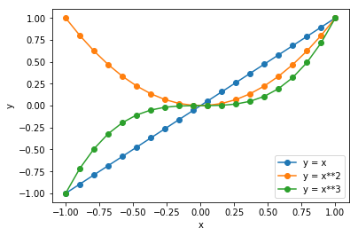

```python
xArr = np.linspace(-1, 1, 20)
plt.plot(xArr, xArr**1, '-o', label='y = x')
plt.plot(xArr, xArr**2, '-o', label='y = x**2')
plt.plot(xArr, xArr**3, '-o', label='y = x**3')
plt.legend()
plt.xlabel('x')
plt.ylabel('y')
plt.show()
```

### Example 2

基本np.array與matplotlib繪圖

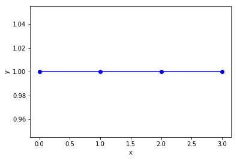

```python
plt.figure()
plt.plot([0,1,2,3], [1,1,1,1], '-ob')
plt.xlabel('x')
plt.ylabel('y')
plt.show()
```

### Question 2

在 Example 2 有一行`plt.plot([0,1,2,3], [1,1,1,1], '-ob')`，其中`'-ob'`控制了一些事情

(1) 把`'-ob'`中的`-`換成`--`，請問此操作的目的是為了改變什麼？

(2) 把`'-ob'`中的`o`換成`x`，請問此操作的目的是為了改變什麼？

(3) 把`'-ob'`中的`b`換成`r`，請問此操作的目的是為了改變什麼？

(4) 請找一個網頁給我（貼網址），有說明到前三小題的事情。（提示：找matplotlib的官方英文說明文件，此題訓練你找說明文件的能力。助教的範例程式有很多東西是上課沒講到的，試著上網自己找找答案跟範例吧！）

Ans:

(1) Change the line style.

(2) Change the marker style.

(3) Change the color of line and marker.

(4) https://matplotlib.org/3.1.1/api/_as_gen/matplotlib.pyplot.plot.html

### Example 3

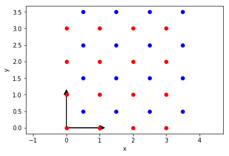

```python
a1 = np.array([1,0])
a2 = np.array([0,1])
atom1 = np.array([0.0, 0.0])
atom2 = np.array([0.5, 0.5])

# plot a1 and a2
plt.arrow(0, 0, a1[0], a1[1], head_width=0.15, head_length=0.15, fc='k', ec='k')
plt.arrow(0, 0, a2[0], a2[1], head_width=0.15, head_length=0.15, fc='k', ec='k')

# plot atoms
for i in range(4):
    for j in range(4):
        atom1_new = atom1 + a1*i + a2*j
        atom2_new = atom2 + a1*i + a2*j
        plt.plot(atom1_new[0], atom1_new[1], 'or')
        plt.plot(atom2_new[0], atom2_new[1], 'ob')

plt.axis('equal')
plt.xlabel('x')
plt.ylabel('y')
plt.show()
```

### Question 3-1

在你們的課本中，Figure 2.11 的圖看起來跟這裡的 Eaxmple 3 有點像，請閱讀 ch2.2，試著回答下述問題。

(1) 請問程式碼中`a1`、`a2`、`atom1`、`atom2`是什麼？

(2) 程式碼中有個`atom1_new = atom1 + a1*i + a2*j`，它做了是麼事情？`a1*i + a2*j`對應到課本的哪個式子且目的為何？

Ans:

(1) Lattice vectors and basis.

(2) It moves `atom1` by `i` times `a1` and `j` times `a2`. `a1*i + a2*j` corresponds Equation 2.1, which is an arbitrarily chosen lattice point.

### Question 3-2: zigzag graphene lattice

以下給定`a1`、`a2`與四個原子位置，試著畫出以下圖形

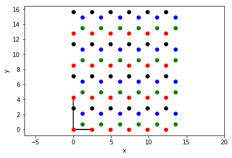

```python
sin30, cos30 = 1/2, np.sqrt(3)/2
acc = 1.42  # [ang] carbon-carbon distance
a1 = np.array([2*acc*cos30,               0.0])
a2 = np.array([        0.0, 2*acc+2*acc*sin30])
atom1 = np.array([      0.0,                0.0])
atom2 = np.array([acc*cos30, atom1[1]+acc*sin30])
atom3 = np.array([acc*cos30, atom2[1]+acc      ])
atom4 = np.array([      0.0, atom3[1]+acc*sin30])

# plot a1 and a2
plt.arrow(0, 0, a1[0], a1[1], head_width=0.15, head_length=0.15, fc='k', ec='k')
plt.arrow(0, 0, a2[0], a2[1], head_width=0.15, head_length=0.15, fc='k', ec='k')

# plot atoms
for i in range(6):
    for j in range(4):
        atom1_new = atom1 + a1*i + a2*j
        atom2_new = atom2 + a1*i + a2*j
        atom3_new = atom3 + a1*i + a2*j
        atom4_new = atom4 + a1*i + a2*j
        plt.plot(atom1_new[0], atom1_new[1], 'or')
        plt.plot(atom2_new[0], atom2_new[1], 'og')
        plt.plot(atom3_new[0], atom3_new[1], 'ob')
        plt.plot(atom4_new[0], atom4_new[1], 'ok')

plt.axis('equal')
plt.xlabel('x')
plt.ylabel('y')
plt.show()
```